# Project Summary

Connor French

8/21/2020

### Data summary

| Resolution | N_cells | N_individuals | N_OTU | Median_individuals | Median_OTU |
| --- | --- | --- | --- | --- | --- |
| 193 km | 244 | 2414373 | 168715 | 2125 | 288 |

### Map of Hill 1

*Note*: Hill 1 is corrected by the number of OTUs, so it scales from 0-1 (Hill 1 / num_otu)

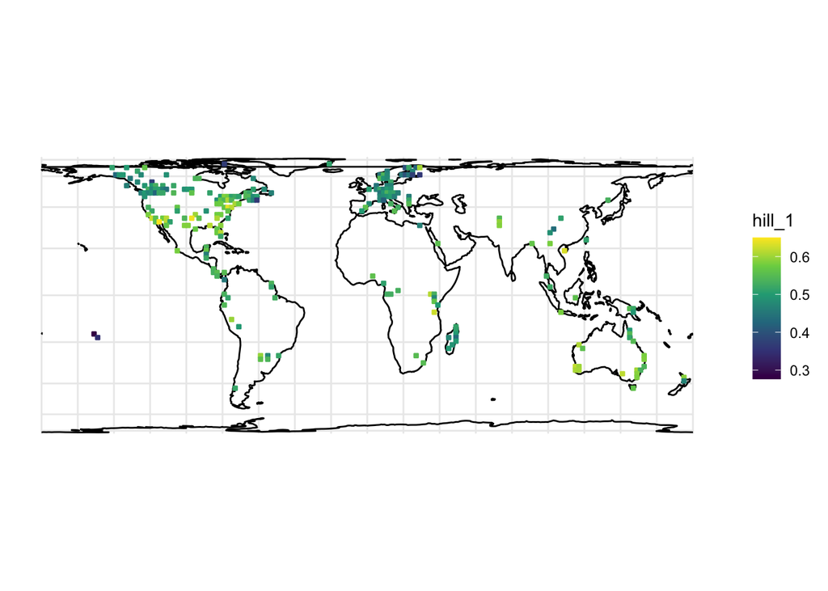

The most general finding was that Hill 1 is higher in regions above freezing point than below.

First, here’s a map of which individuals are above and below the freeze line (where minimum temperature of the coldest month is above zero). They roughly follow a temperate/subtropical distribution.

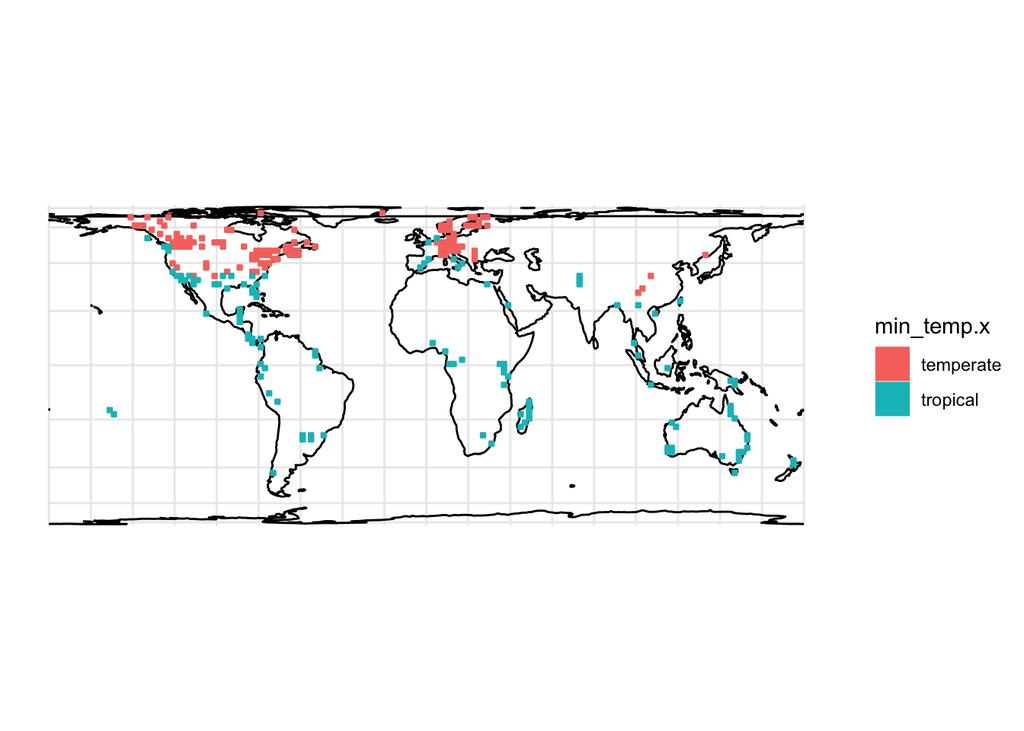

### Hill 1 across freezing point

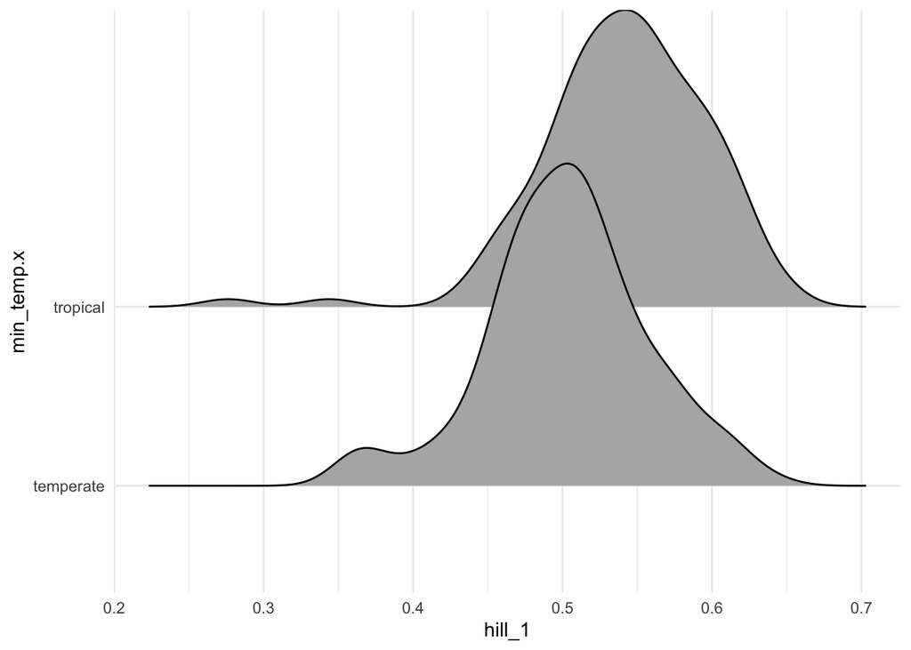

### Species richness isn’t a reliable predictor

My time over the last week has been spent wrangling over 70 million GBIF records down to a reasonable data set to quantify insect species richness across the globe, but it doesn’t look like the data will work out.

First, it looks like species richness just reflects sampling effort.

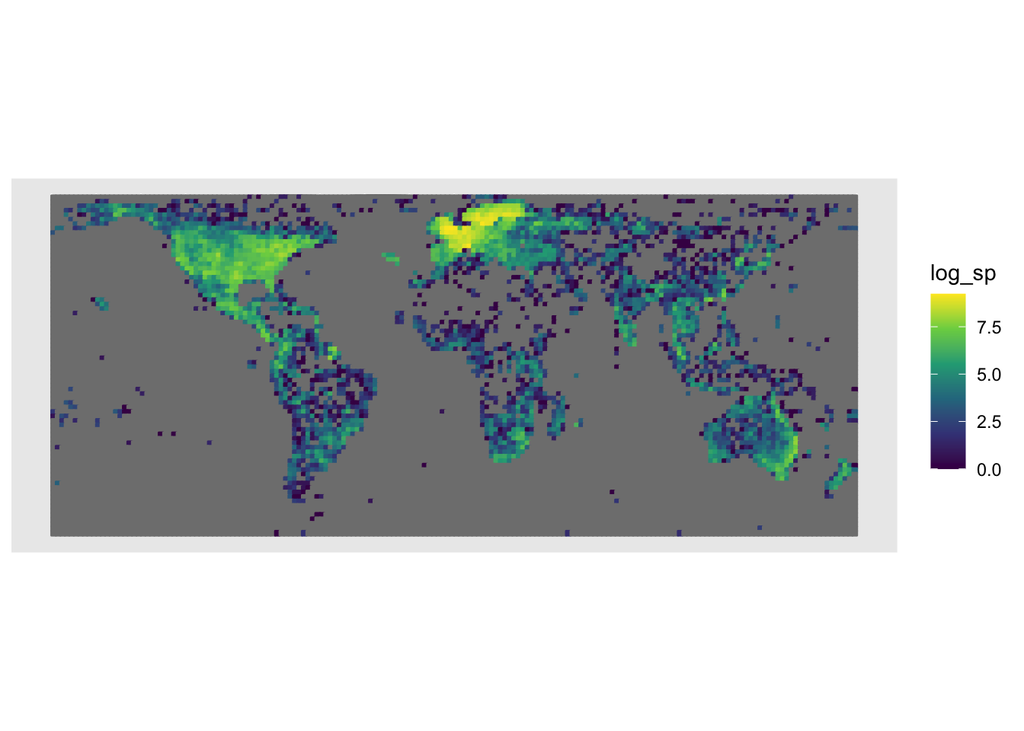

Also, there is a lot of missing data when combined with the existing data set. (from 244 to 170). A weak correlation with hill 1 (r = 0.14, R2 < 0.02).

### Modeling

I used a hierarchical Bayesian regression approach, where the regression is grouped by the temperate-tropical divide. I’m working on controlling for spatial autocorrelation, but haven’t found the right covariance structure.